# Visualizing accessibility measures (*Dissemination area* level)

Bruno Santos & Antonio Paez

2025-03-20

# Introduction

This Rmarkdown file is part of the [**CommuteCA**](https://github.com/dias-bruno/CommuteCA) package. This package was created in conjunction with the office of the [*Research Data Center* at *McMaster University*](https://rdc.mcmaster.ca/), the [*Sherman Centre for Digital Scholarship*](https://scds.ca/) and the [*Mobilizing Justice*](https://mobilizingjustice.ca/).

The Mobilizing Justice project is a multidisciplinary and multi-sector collaboration with the objective of understand and address transportation poverty in Canada and to improve the well-being of Canadians at risk of transport poverty. The Social Sciences and Humanities Research Council (SSRHC) has provided funding for the project, which was created by an unprecedented alliance of academics from various Canadian provinces and institutions, transportation firms, and nonprofit organizations

The [**CommuteCA**](https://github.com/dias-bruno/CommuteCA) R package was created to develop standardized methods for transport analysis in research, particularly for analysis using the [*2021 Census of Population*](https://www12.statcan.gc.ca/census-recensement/index-eng.cfm) from Statistics Canada. We focused our efforts on the [*Commuting Reference Guide*](https://www12.statcan.gc.ca/census-recensement/2021/ref/98-500/011/98-500-x2021011-eng.cfm), which provides valuable variables and information on commuting for the Canadian population aged 15 and older living in private households.

After obtaining the accessibility measures for our study area, in this `R` Markdown we will visualize the measure in form of maps.

## Suggested Readings

- Soukhov, Anastasia, Antonio Paez, Christopher D Higgins, and Moataz Mohamed. 2023.”Introducing Spatial Availability, a Singly-Constrained Measure of Competitive Accessibility.” *Plos One* 18 (1): e0278468.
- Soukhov, A., Páez, A. (2024). Accessibility analysis for planning applications (Report No. MJ-A2-0002). Mobilizing Justice. https://github.com/soukhova/MJ-Accessibility-Blogs
- Pereira, Rafael H. M.; Herszenhut, Daniel. Introduction to urban accessibility: a practical guide with R. Rio de Janeiro: Ipea, 2023. 152 p. ISBN: 978-65-5635-065-3. DOI: http://dx.doi.org/9786556350653.
- Soukhov A, Tarriño-Ortiz J, Soria-Lara JA, Páez A (2024) Multimodal spatial availability: A singly-constrained measure of accessibility considering multiple modes. PLoS ONE 19(2): e0299077. https://doi.org/10.1371/journal.pone.0299077

## Data

The data used in this R markdown is the output of the previous `R` markdown, in which we calculated accessibility and spatial availability for our study area. The methodology described here is applicable to the results obtained through the synthetic or original census survey. Additionally, we will use the dissemination areas (DA) geometry, available in this package, to plot maps of the study area.

# Let’s code!

Load the packages:

```r
library(CommuteCA)
library(dplyr)# A Grammar of Data Manipulation
library(ggplot2) # Create Elegant Data Visualizations Using the Grammar of Graphics
library(RColorBrewer) # color schemes for maps (and other graphics) designed
library(scales) # for scaling data
library(sf) # support for simple features, a standardized way to encode spatial vector data
library(tmap) # thematic maps
library(tidyr) # tidying data
```

Reading the tables:

```r
output_folder <- paste0(here::here(),"/data-raw/DA/output/PCD3520/")
```

```r
HT_mode <- read.csv(paste0(output_folder, "HT_mode_original.csv"))
HT <- read.csv(paste0(output_folder, "HT_general_original.csv"))
SA_mode <- read.csv(paste0(output_folder, "SA_mode_original.csv"))
SA <- read.csv(paste0(output_folder, "SA_general_original.csv"))
land_use_mode <- read.csv(paste0(output_folder, "land_use_mode_original_DA.csv"))
land_use_general <- read.csv(paste0(output_folder, "land_use_general_original_DA.csv"))
```

Reading the DA geometries:

```r
data("dissemination_areas_ca21.rda")
data("census_divisions_ca21.rda")
```

Selecting only the DA in our study area:

```r
DA <- dissemination_areas_ca21

DA <- DA %>%
  filter(PCD %in% (unique(substr(unique(land_use_general$PRCDDA), 1,4)))) # It will select the dissemination areas with PCD codes within our study area

CD <- census_divisions_ca21

CD <- CD %>%
  filter(CDUID %in% (unique(DA$PCD))) # It will select the census division of our study area
```

Merging the DA with the accessibility measures tables:

```r
names(DA)[1] <- "PRCDDA"

mode_metrics_da <-
  expand.grid(PRCDDA = unique(DA$PRCDDA), PwMode = unique(HT_mode$PwMode)) %>%
  full_join(DA, by = "PRCDDA") %>%
  mutate(PRCDDA = as.numeric(PRCDDA)) %>%
  full_join(HT_mode, by = c("PRCDDA", "PwMode")) %>%
  full_join(SA_mode, by = c("PRCDDA", "PwMode")) %>%
  full_join(land_use_mode[,c("PRCDDA","PwMode","labour_force")], by = c("PRCDDA", "PwMode"))

mode_metrics_da[is.na(mode_metrics_da$HT_im),]$HT_im <- 0
mode_metrics_da[is.na(mode_metrics_da$SA_im),]$SA_im <- 0
mode_metrics_da[is.na(mode_metrics_da$labour_force),]$labour_force <- 0

mode_metrics_da_sf <- st_as_sf(mode_metrics_da, crs = st_crs(DA))
```

Preparing the tables to plot the maps:

```r
# Hansen
HT_metrics_da <- DA %>%
  mutate(PRCDDA = as.numeric(PRCDDA)) %>%
  full_join(HT, by = "PRCDDA") %>%
  full_join(land_use_general, by ="PRCDDA")

HT_metrics_da[is.na(HT_metrics_da$HT_i),]$HT_i <- 0
HT_metrics_da[is.na(HT_metrics_da$labour_force),]$labour_force <- 0
HT_metrics_da[is.na(HT_metrics_da$jobs),]$jobs <- 0

# Spatial Availability
SA_metrics_da <- DA %>%
  mutate(PRCDDA = as.numeric(PRCDDA)) %>%
  full_join(SA, by = "PRCDDA") %>%
  full_join(land_use_general, by ="PRCDDA")

SA_metrics_da[is.na(SA_metrics_da$SA_i),]$SA_i <- 0
SA_metrics_da[is.na(SA_metrics_da$labour_force),]$labour_force <- 0
SA_metrics_da[is.na(SA_metrics_da$jobs),]$jobs <- 0
```

## Visualizing the accessibility measures with maps

Plotting the count of people within the labour force and count of job opportunities in each DA:

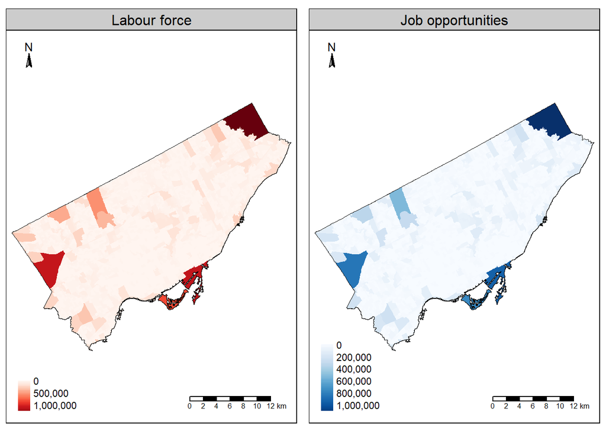

```r
labour_force_plot <- tm_shape(HT_metrics_da) +
   tm_polygons("labour_force",
              style = "cont",
              palette = "Reds",
              title = " ",
              border.col = NULL) +
  tm_shape(CD) +
  tm_borders("black", lwd=0.5) +
  tm_scale_bar(position = c("right", "bottom"))+
  tm_compass(position = c("left", "top"), size=1.0)  +
  tm_layout(legend.outside = FALSE,
            legend.position = c("left", "bottom"),
            panel.labels = "Labour force")

jobs_plot <- tm_shape(SA_metrics_da) +
   tm_polygons("jobs",
              style = "cont",
              palette = "Blues",
              title = " ",
              border.col = NULL) +
  tm_shape(CD) +
  tm_borders("black", lwd=0.5) +
  tm_scale_bar(position = c("right", "bottom"))+
  tm_compass(position = c("left", "top"), size=1.0)  +
  tm_layout(legend.outside = FALSE,
            legend.position = c("left", "bottom"),
            panel.labels = "Job opportunities")

lf_jobs_DA <- tmap_arrange(labour_force_plot, jobs_plot, ncol = 2)

tmap_save(lf_jobs_DA,
          paste0(output_folder,"lf_jobs_DA.jpg"),
          width = 20,
          height = 15,
          units = "cm",
          dpi = 300)

lf_jobs_DA
```

Plotting the accessibility measures:

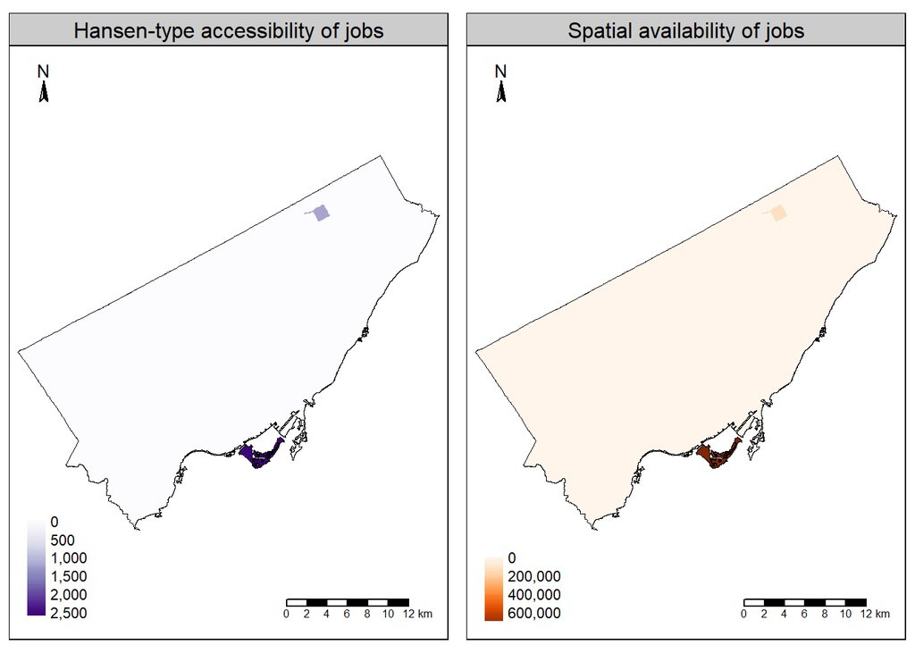

```r
ht_plot <- tm_shape(HT_metrics_da) +
   tm_polygons("HT_i",
              style = "cont",
              palette = "Purples",
              title = " ",
              border.col = NULL) +
  tm_shape(CD) +
  tm_borders("black", lwd=0.5) +
  tm_scale_bar(position = c("right", "bottom"))+
  tm_compass(position = c("left", "top"), size=1.0)  +
  tm_layout(legend.outside = FALSE,
            legend.position = c("left", "bottom"),
            panel.labels = "Hansen-type accessibility of jobs")

sa_plot <- tm_shape(SA_metrics_da) +
   tm_polygons("SA_i",
              style = "cont",
              palette = "Oranges",
              title = " ",
              border.col = NULL) +
  tm_shape(CD) +
  tm_borders("black", lwd=0.5) +
  tm_scale_bar(position = c("right", "bottom"))+
  tm_compass(position = c("left", "top"), size=1.0)  +
  tm_layout(legend.outside = FALSE,
            legend.position = c("left", "bottom"),
            panel.labels = "Spatial availability of jobs")

HT_SA_DA <- tmap_arrange(ht_plot, sa_plot, ncol = 2)

tmap_save(HT_SA_DA,
          paste0(output_folder,"HT_SA_DA.jpg"),
          width = 20,
          height = 15,
          units = "cm",
          dpi = 300)

HT_SA_DA
```

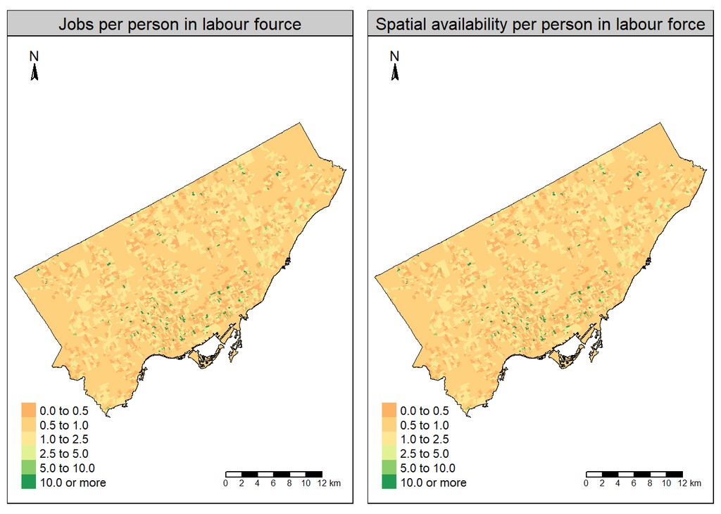

```r
HT_metrics_da$jobs_per_lf <- HT_metrics_da$jobs / HT_metrics_da$labour_force

HT_metrics_da <- HT_metrics_da %>%
  mutate(jobs_per_lf = case_when(
    jobs == 0 & labour_force == 0 ~ 0,
    labour_force == 0 & jobs != 0 ~ jobs,
    TRUE ~ jobs_per_lf))

jobs_per_labour_force <- tm_shape(HT_metrics_da) +
   tm_polygons("jobs_per_lf",
              style = "fixed",
              breaks = c(0, 0.5, 1, 2.5, 5, 10, Inf),
              palette = "RdYlGn",
              title = " ",
              border.col = NULL) +
  tm_shape(CD) +
  tm_borders("black", lwd=0.5) +
  tm_scale_bar(position = c("right", "bottom"))+
  tm_compass(position = c("left", "top"), size=1.0)  +
  tm_layout(legend.outside = FALSE,
            legend.position = c("left", "bottom"),
            panel.labels = "Jobs per person in labour fource")

SA_metrics_da$SA_per_lf <- SA_metrics_da$jobs / SA_metrics_da$labour_force

SA_metrics_da <- SA_metrics_da %>%
  mutate(SA_per_lf = case_when(
    jobs == 0 & labour_force == 0 ~ 0,
    labour_force == 0 & jobs != 0 ~ jobs,
    TRUE ~ SA_per_lf))

SA_per_labour_force <- tm_shape(SA_metrics_da) +
   tm_polygons("SA_per_lf",
              style = "fixed",
              breaks = c(0, 0.5, 1, 2.5, 5, 10, Inf),
              palette = "RdYlGn",
              title = " ",
              border.col = NULL) +
  tm_shape(CD) +
  tm_borders("black", lwd=0.5) +
  tm_scale_bar(position = c("right", "bottom"))+
  tm_compass(position = c("left", "top"), size=1.0)  +
  tm_layout(legend.outside = FALSE,
            legend.position = c("left", "bottom"),
            panel.labels = "Spatial availability per person in labour force")

jobs_SA_per_lf_DA <- tmap_arrange(jobs_per_labour_force, SA_per_labour_force, ncol = 2)


tmap_save(jobs_SA_per_lf_DA,
          paste0(output_folder,"jobs_SA_per_lf_DA.jpg"),
          width = 20,
          height = 15,
          units = "cm",
          dpi = 300)

jobs_SA_per_lf_DA
```

## Visualizing the accessibility measures by transportation modes with maps

Visualizing the total labour force by transportation mode:

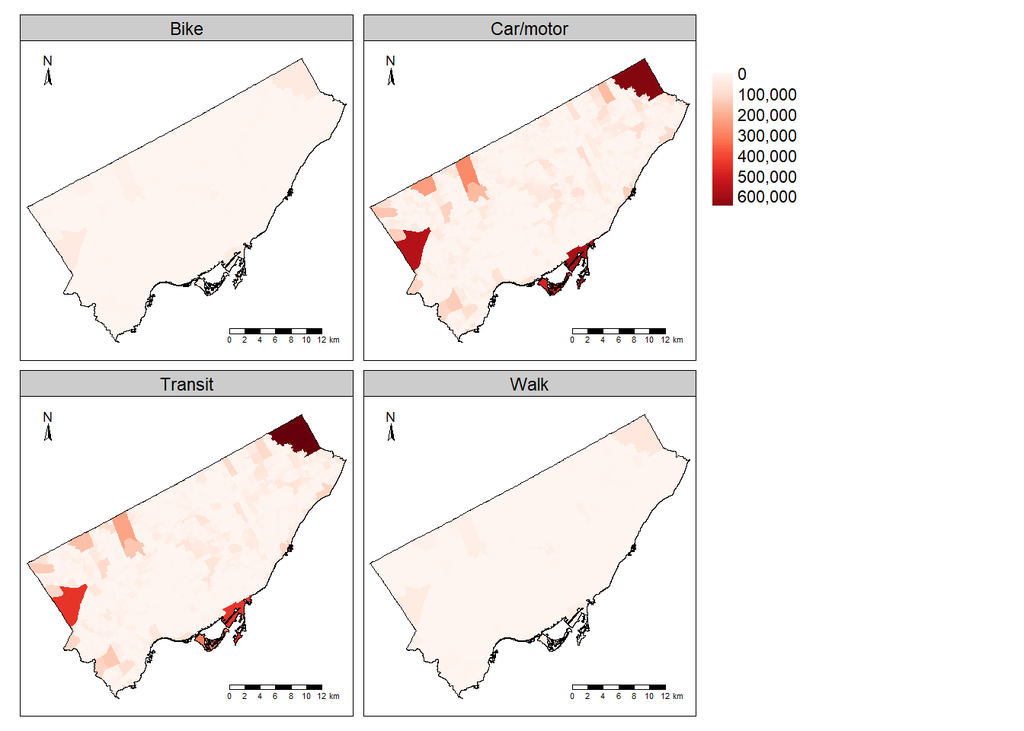

```r
total_pop_by_mode_DA <- tm_shape(mode_metrics_da_sf) +
   tm_polygons("labour_force",
              style = "cont",
              palette = "Reds",
              title = " ",
              border.col = NULL) +
   tm_facets(by = "PwMode") +
   tm_scale_bar(position = c("right", "bottom")) +
   tm_compass(position = c("left", "top"), size = 1.0) +
   tm_shape(CD) +
   tm_borders("black", lwd=0.5)

tmap_save(total_pop_by_mode_DA,
          paste0(output_folder,"total_pop_by_mode_DA.jpg"),
          width = 20,
          height = 20,
          units = "cm",
          dpi = 300)

total_pop_by_mode_DA
```

Visualizing the Hansen-type accessibility by transportation mode:

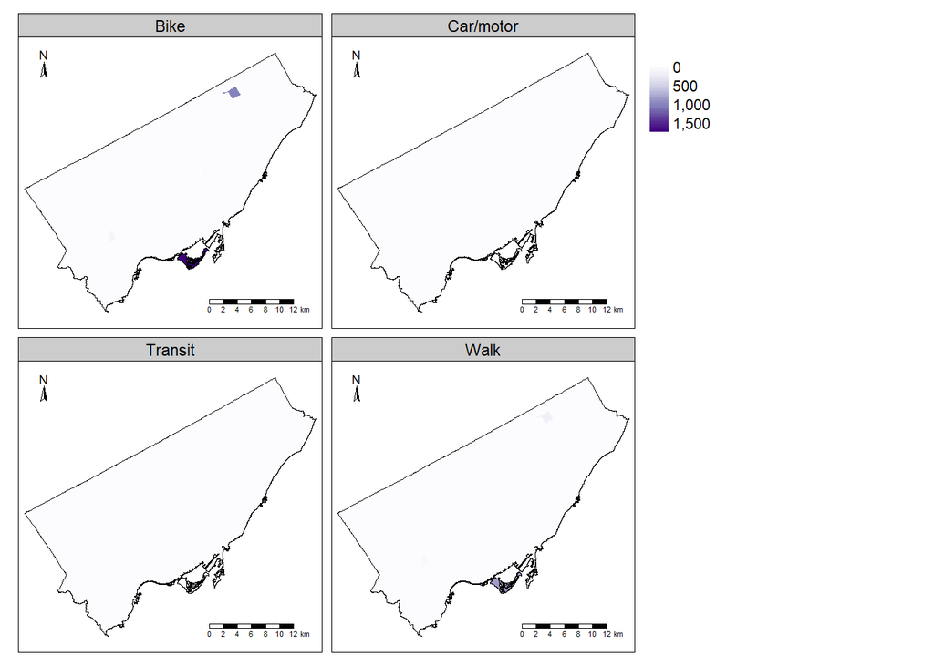

```r
HT_by_mode_DA <- tm_shape(mode_metrics_da_sf) +
   tm_polygons("HT_im",
              style = "cont",
              palette = "Purples",
              title = " ",
              border.col = NULL) +
  tm_scale_bar(position = c("right", "bottom"))+
  tm_compass(position = c("left", "top"), size=1.0)  +
  tm_facets(by="PwMode") +
   tm_shape(CD) +
   tm_borders("black", lwd=0.5)

tmap_save(HT_by_mode_DA,
          paste0(output_folder,"HT_by_mode_DA.jpg"),
          width = 20,
          height = 20,
          units = "cm",
          dpi = 300)

HT_by_mode_DA
```

Visualizing the Spatial Availability by transportation mode:

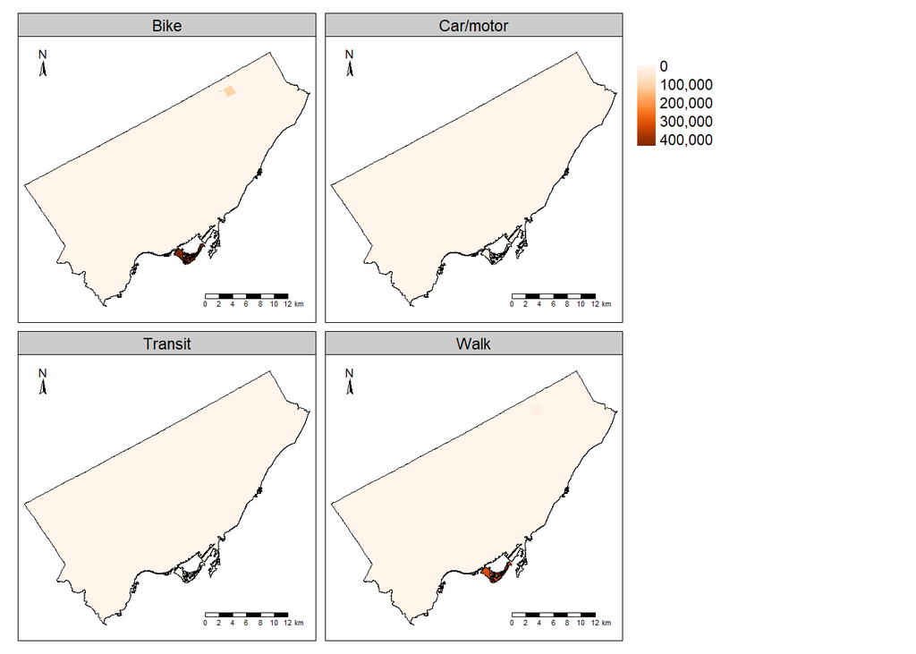

```r
SA_by_mode_DA <- tm_shape(mode_metrics_da_sf) +
   tm_polygons("SA_im",
              style = "cont",
              palette = "Oranges",
              title = " ",
              border.col = NULL) +
  tm_scale_bar(position = c("right", "bottom"))+
  tm_compass(position = c("left", "top"), size=1.0)  +
  tm_facets(by="PwMode") +
   tm_shape(CD) +
   tm_borders("black", lwd=0.5)

tmap_save(SA_by_mode_DA,
          paste0(output_folder,"SA_by_mode_DA.jpg"),
          width = 20,
          height = 20,
          units = "cm",
          dpi = 300)

SA_by_mode_DA
```

Computing of the labour force by transportation mode:

```r
total_pop <- sum(land_use_mode$labour_force)
total_SA <- sum(mode_metrics_da$SA_im)

modal_SA_percents <- mode_metrics_da %>%
  group_by(PwMode) %>%
  summarize(total_labour_fource = sum(labour_force),
            SA_meam = mean(SA_im),
            SA_sum = sum(SA_im),
            perc_SA = sum(SA_im)/total_SA,
            perc_pop= sum(labour_force)/total_pop)

modal_SA_long <- modal_SA_percents %>%
  pivot_longer(cols = c(perc_SA, perc_pop), names_to = "perc", values_to = "measure")
```

Visualizing the share of labour force and spatial availability by transportation mode:

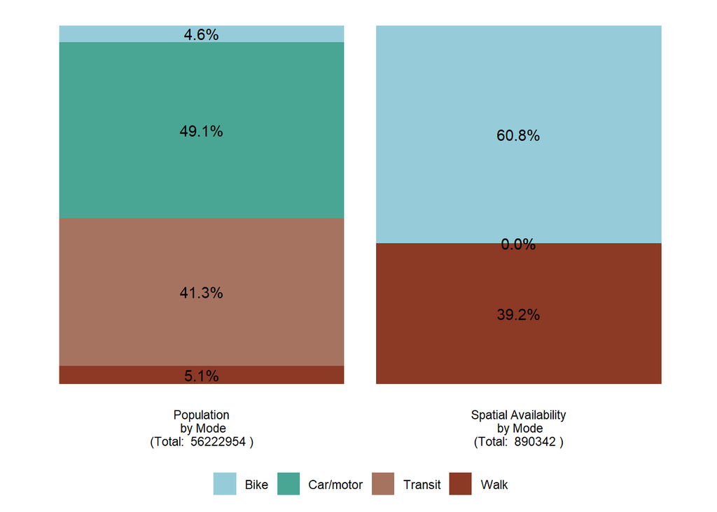

```r
Pop_SA_by_mode_DA <- ggplot(modal_SA_long,
      aes(x = perc, y = measure, fill = PwMode, label = measure %>% percent(accuracy = 0.1))) +
      scale_x_discrete(labels = c(
      "perc_SA" = paste("Spatial Availability\n by Mode\n(Total: ", round(total_SA), ")"),
      "perc_pop" = paste("Population\n by Mode\n(Total: ", round(total_pop), ")") )) +
  geom_col() +
  scale_fill_manual(values = c("#96CCD9","#49A695", "#A67360", "#8C3926")) +
  geom_text(position = position_stack(vjust=0.5), color="black") +
  theme_classic() +
  theme(axis.ticks = element_blank(),
        axis.title = element_blank(),
        axis.line = element_blank(),
        axis.text.y = element_blank(),
        axis.text = element_text(color="black"),
        legend.position = "bottom",
        legend.title = element_blank())


ggsave(file = paste0(output_folder,"Pop_SA_by_mode_DA.jpg"),
       plot = Pop_SA_by_mode_DA,
       width = 10,
       height = 10,
       units = "in",
       dpi = 300)

Pop_SA_by_mode_DA
```